# Assignment (Intro to R)

Abhishek Bhatia

19th September 2019

1. The scores of four teams for three rounds in a competition is saved in three files as r1.txt, r2.txt and r3.txt
1. Import data from the three files and create a data frame with the team name as row names and the scores of the rounds in three different columns

```r
fnames <- paste0("r", 1:3, ".txt")
# Suppressing warning as the R expects the last line must be empty
# Reading in each file as a list of dataframes
contents <- suppressWarnings(lapply(fnames,
                                    function(f) read.table(paste("data",
                                                                 f,
                                                                 sep = "/")
                                                           )))
names(contents) <- fnames

# list of dataframes
contents
```

```
## $r1.txt
##        Round1
## Team A      3
## Team C      5
## Team B      9
## Team D      3
##
## $r2.txt
##        Round2
## Team B      5
## Team A      7
## Team C      7
## Team D      3
##
## $r3.txt
##        Round3
## Team D      6
## Team C      8
## Team A      9
## Team B      2
```

```r
# Since the row names of dataframes are unordered, below code will give
# added rowname column to each dataframe in list
lapply(contents, function(d) data.frame(d, rowname = row.names(d)))
```

```
## $r1.txt
##        Round1 rowname
## Team A      3  Team A
## Team C      5  Team C
## Team B      9  Team B
## Team D      3  Team D
##
## $r2.txt
##        Round2 rowname
## Team B      5  Team B
## Team A      7  Team A
## Team C      7  Team C
## Team D      3  Team D
##
## $r3.txt
##        Round3 rowname
## Team D      6  Team D
## Team C      8  Team C
## Team A      9  Team A
## Team B      2  Team B
```

```r
# Above will be helpful to merge multiple dataframes
# Finally we can apply Reduce by applying merge,
# Reduce function: applies a function successively in a cumulative manner
df <- Reduce(merge, lapply(contents,
                           function(d) data.frame(d, rowname = row.names(d))))

# Add rownames
row.names(df) <- df[, "rowname"]

# Finally dropping the rownum column
df <- df[ , -which(names(df) == "rowname")]
df
```

```
##        Round1 Round2 Round3
## Team A      3      7      9
## Team B      9      5      2
## Team C      5      7      8
## Team D      3      3      6
```

2. Find the total of the four teams and add as column in the data

```r
df[, "Team.Total"] <- rowSums(df)
df
```

```
##        Round1 Round2 Round3 Team.Total
## Team A      3      7      9         19
## Team B      9      5      2         16
## Team C      5      7      8         20
## Team D      3      3      6         12
```

3. Create a file which includes the winning team name with its total marks as a list (Name of the teams should be taken from the files).

```r
winning.team <- df[which.max(df$Team.Total), ]

# TODO: Write in a more DRY (Don't Repeat Yourself) way.
to.write <- paste0(
  "Team Name",
  "\n",
  row.names(winning.team),
  "\n",
  "Team Total",
  "\n",
  winning.team$Team.Total,
  "\n")

# This is what we want to write
cat(to.write)
```

```
## Team Name
## Team C
## Team Total
## 20
```

```r
# Write to the output file
writeLines(to.write, con = "output/winning_team.txt")

# Or capture the exact print output to the file
output <- list("Team Name"=row.names(winning.team),
               "Team Total"=winning.team[, "Team.Total"])

# TODO: Regenerate the object using capture.output output str
capture.output(output, file = "output/winning_team2.txt")
```

2. Write a function of your own that takes in two 2x2 matrices (A and B) and  
   performs  
   matrix multiplication (without using *%*).  
   Output from that function should be a list with the following objects,
1. A
2. B
3. AB
4. Whether AB = BA (Either TRUE or FALSE)

```r
matmulalgo <- function(A, B){
  AB <- matrix(0, 2, 2)
  # TODO: Implement using some apply function
  for (i in 1:2){
    for (j in 1:2){
      AB[i, j] <- sum(A[i, ]*B[, j])
    }
  }

  return(AB)
}


matmul <- function(A, B){
  # Check if shape is 2x2
  shape <- lapply(list(A, B), function(X) identical(dim(X), c(2L, 2L)))
  A.B.22 <- Reduce("&", shape)
  if (!A.B.22){
    stop("Unsupported dimensions: Please provide 2x2 matrices!")
  }

  AB <- matmulalgo(A, B)
  BA <- matmulalgo(B, A)

  AB.eq.BA <- identical(AB, BA)

  res <- list(A=A, B=B, AB=AB, AB.eq.BA=AB.eq.BA)
  return(res)
}
```

3. Using state.x77 dataset, write line(s) of code to return the following

```r
# Converting to data frame since originally it's a matrix
df <- as.data.frame(state.x77)
```

1. Arrange the states in decreasing order of population. Among the first 10 states which is having maximum Illiteracy (only name of the state)

```r
df.pop.dec <- df[order(df$Population, decreasing = T), ]
# Decreasing order of Population dataframe
head(df.pop.dec)
```

```
##              Population Income Illiteracy Life Exp Murder HS Grad Frost
## California        21198   5114        1.1    71.71   10.3    62.6    20
## New York          18076   4903        1.4    70.55   10.9    52.7    82
## Texas             12237   4188        2.2    70.90   12.2    47.4    35
## Pennsylvania      11860   4449        1.0    70.43    6.1    50.2   126
## Illinois          11197   5107        0.9    70.14   10.3    52.6   127
## Ohio              10735   4561        0.8    70.82    7.4    53.2   124
##                Area
## California   156361
## New York      47831
## Texas        262134
## Pennsylvania  44966
## Illinois      55748
## Ohio          40975
```

```r
# Maximum illiteracy for df.pop.dec
row.names(subset(df.pop.dec[1:10, ], Illiteracy == max(Illiteracy)))
```

```
## [1] "Texas"
```

2. Name the states where population is more than 15000 as well as income more than 4500

```r
subset(df, (Population > 15000) & (Income > 4500))
```

```
##            Population Income Illiteracy Life Exp Murder HS Grad Frost
## California      21198   5114        1.1    71.71   10.3    62.6    20
## New York        18076   4903        1.4    70.55   10.9    52.7    82
##              Area
## California 156361
## New York    47831
```

3. Compute population per unit area (population/area) of all the states and add it as a column with column name as “Population Density”.

```r
df[, "Population Density"] <- df$Population/df$Area
```

4. Plot a bar graph with proper labels and title of top five states in Population Density.

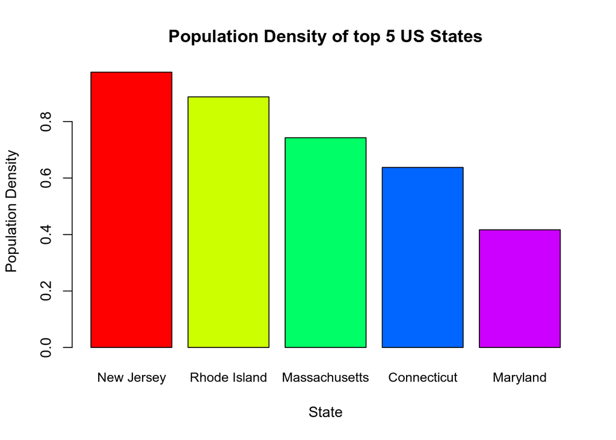

```r
df.popdens.dec <- df[order(df$`Population Density`, decreasing = T), ]


pop.dens.topN <- df.popdens.dec[1:5, "Population Density"]
names(pop.dens.topN) <- row.names(df.popdens.dec[1:5, ])

barplot(
  pop.dens.topN,
  cex.names = 0.9,
  ylab = "Population Density",
  xlab = "State",
  main = "Population Density of top 5 US States",
  col = rainbow(5)
)
```